# A2.2 LDA y árboles de decisión

## 1. Definición del problema y origen de los datos

### 1.1 Descripción del problema

En esta actividad se aborda un problema de clasificación supervisada multiclase, cuyo objetivo es predecir la especie de una flor del género Iris a partir de ciertas características físicas medidas en la planta. Este tipo de problema es común dentro del área de aprendizaje automático, ya que consiste en identificar patrones dentro de un conjunto de variables numéricas que permitan distinguir correctamente entre distintas categorías.

Para este análisis se utiliza el Iris Dataset. El cual se saco del UCI Machine Learning Repository, una de las colecciones más reconocidas de datasets para investigación en aprendizaje automático.

El conjunto de datos contiene mediciones morfológicas de flores pertenecientes a tres especies diferentes:

- Iris setosa
- Iris versicolor
- Iris virginica

Cada observación del dataset representa una flor individual y está descrita mediante cuatro variables numéricas:

- Sepal length (cm): longitud del sépalo
- Sepal width (cm): ancho del sépalo
- Petal length (cm): longitud del pétalo
- Petal width (cm): ancho del pétalo

Estas variables conforman el conjunto de variables predictoras (X) del modelo. Por otro lado, la variable Class representa la variable de salida (y), la cual indica la especie de la flor a la que pertenece cada observación.

El objetivo del análisis es utilizar estas mediciones físicas para construir modelos de clasificación capaces de identificar correctamente la especie de la flor. En particular, se compararán dos enfoques distintos de clasificación: Linear Discriminant Analysis (LDA) y árboles de decisión, analizando tanto su comportamiento geométrico como su desempeño predictivo.

### 1.2 Carga del conjunto de datos

Para este análisis se utiliza la implementación del dataset Iris incluida dentro de la biblioteca Scikit-learn, la cual contiene una versión limpia y estructurada del dataset original del repositorio UCI.

A continuación, se carga el conjunto de datos y se transforma en un DataFrame para facilitar su manipulación y análisis.

```python
import numpy as np
import pandas as pd

from sklearn.datasets import load_iris

# cargar dataset
iris = load_iris(as_frame=True)

# convertir a dataframe
db = iris.frame.copy()

# agregar nombres de clases
db["Class"] = db["target"].map(dict(enumerate(iris.target_names)))

# eliminar columna target numérica
db = db.drop(columns=["target"])

# visualizar primeras filas
db.head()
```

|  | sepal length (cm) | sepal width (cm) | petal length (cm) | petal width (cm) | Class |
| --- | --- | --- | --- | --- | --- |
| 0 | 5.1 | 3.5 | 1.4 | 0.2 | setosa |
| 1 | 4.9 | 3.0 | 1.4 | 0.2 | setosa |
| 2 | 4.7 | 3.2 | 1.3 | 0.2 | setosa |
| 3 | 4.6 | 3.1 | 1.5 | 0.2 | setosa |
| 4 | 5.0 | 3.6 | 1.4 | 0.2 | setosa |

### 1.3 Dimensión del dataset y variables

Antes de construir cualquier modelo, es importante analizar la estructura del conjunto de datos, incluyendo el número de observaciones y las variables disponibles.

```python
print("Dimensiones del dataset:")
print(db.shape)

print("\nNombres de las variables:")
print(db.columns)
```

```
Dimensiones del dataset:
(150, 5)

Nombres de las variables:
Index(['sepal length (cm)', 'sepal width (cm)', 'petal length (cm)',
       'petal width (cm)', 'Class'],
      dtype='object')
```

### 1.4 Distribución de clases

En problemas de clasificación es fundamental analizar el balance de clases, ya que un fuerte desbalance podría sesgar el aprendizaje del modelo hacia la clase mayoritaria.

```python
print("Distribución de clases:")
print(db["Class"].value_counts())
```

```
Distribución de clases:
Class
setosa        50
versicolor    50
virginica     50
Name: count, dtype: int64
```

### 1.5 Visualización del balance de clases

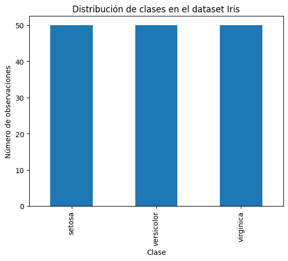

```python
import matplotlib.pyplot as plt

db["Class"].value_counts().plot(kind="bar")

plt.title("Distribución de clases en el dataset Iris")
plt.xlabel("Clase")
plt.ylabel("Número de observaciones")

plt.show()
```

### 1.6 Resultados obtenidos

A partir de la ejecución del código anterior, se observa que el conjunto de datos Iris contiene 150 observaciones y 5 variables en total. Cuatro de estas variables corresponden a las variables predictoras utilizadas para entrenar los modelos de clasificación:

- sepal length (cm)
- sepal width (cm)
- petal length (cm)
- petal width (cm)

Mientras que la quinta variable, Class, corresponde a la variable de salida, la cual indica la especie de la flor.

Estas variables representan mediciones físicas de distintas partes de la flor y constituyen la información que los modelos utilizarán para identificar patrones que permitan distinguir entre las diferentes especies.

El análisis de la distribución de clases muestra que el dataset se encuentra perfectamente balanceado, ya que cada una de las tres especies de flores contiene exactamente 50 observaciones:

- setosa: 50
- versicolor: 50
- virginica: 50

Este balance es particularmente favorable para el entrenamiento de modelos de clasificación, ya que evita que el algoritmo se incline hacia una clase dominante. Cuando un dataset presenta clases desbalanceadas, algunos modelos pueden obtener una alta exactitud simplemente prediciendo la clase mayoritaria, lo cual no refleja un buen desempeño real.

La gráfica de barras generada confirma visualmente esta distribución equilibrada entre las tres clases, mostrando que cada especie posee el mismo número de observaciones dentro del conjunto de datos.

Debido a este equilibrio en las clases, el dataset Iris resulta especialmente adecuado para comparar distintos métodos de clasificación, ya que permite evaluar el desempeño de los modelos sin que exista un sesgo provocado por un desbalance en las categorías.

## 2. Partición de los datos en entrenamiento y prueba

### 2.1 Justificación de la partición

Para evaluar correctamente el desempeño de los modelos de clasificación es necesario separar el conjunto de datos en dos subconjuntos distintos: datos de entrenamiento y datos de prueba. Esta separación permite medir la capacidad del modelo para generalizar a nuevas observaciones, es decir, su habilidad para realizar predicciones correctas sobre datos que no fueron utilizados durante el proceso de aprendizaje.

En este análisis se utiliza una partición 70% / 30%, donde aproximadamente el 70% de las observaciones se destinan al entrenamiento del modelo, mientras que el 30% restante se reserva para la evaluación del desempeño del modelo.

La elección de esta proporción representa un equilibrio entre dos necesidades importantes del proceso de modelado. Por un lado, el modelo requiere una cantidad suficiente de datos de entrenamiento para poder identificar adecuadamente los patrones presentes en las variables predictoras. Si el conjunto de entrenamiento fuera demasiado pequeño, el modelo podría no aprender correctamente la relación entre las variables y la clase objetivo.

Por otro lado, también es necesario contar con un conjunto de prueba lo suficientemente grande que permita realizar una evaluación confiable del modelo. Si el conjunto de prueba fuera demasiado pequeño, las métricas de desempeño podrían ser inestables o poco representativas del comportamiento real del modelo.

Además, en este análisis se utiliza una partición estratificada, lo que significa que la proporción de cada clase se mantiene aproximadamente igual tanto en el conjunto de entrenamiento como en el de prueba. Esto es especialmente importante en problemas de clasificación multiclase, ya que asegura que todas las categorías estén representadas en ambos subconjuntos, evitando sesgos en la evaluación del modelo.

```python
from sklearn.model_selection import train_test_split

# definir variables
X = db.drop(columns=["Class"])
y = db["Class"]

# partición 70 / 30 estratificada
X_train, X_test, y_train, y_test = train_test_split(
    X,
    y,
    test_size=0.30,
    stratify=y,
    random_state=0
)

print("Dimensiones de entrenamiento:")
print(X_train.shape)

print("\nDimensiones de prueba:")
print(X_test.shape)

print("\nDistribución de clases en entrenamiento:")
print(y_train.value_counts())

print("\nDistribución de clases en prueba:")
print(y_test.value_counts())
```

```
Dimensiones de entrenamiento:
(105, 4)

Dimensiones de prueba:
(45, 4)

Distribución de clases en entrenamiento:
Class
virginica     35
setosa        35
versicolor    35
Name: count, dtype: int64

Distribución de clases en prueba:
Class
virginica     15
setosa        15
versicolor    15
Name: count, dtype: int64
```

### 2.2 Resultados de la partición de los datos

A partir de la ejecución del código anterior se obtuvo la partición del conjunto de datos en dos subconjuntos: entrenamiento y prueba.

El conjunto de entrenamiento contiene 105 observaciones y 4 variables predictoras, mientras que el conjunto de prueba contiene 45 observaciones y las mismas 4 variables. Esta división corresponde exactamente a la proporción 70% / 30% definida previamente para el análisis.

Adicionalmente, debido a que se utilizó un muestreo estratificado, la distribución de clases se mantiene equilibrada en ambos subconjuntos. En el conjunto de entrenamiento se observa la siguiente distribución:

- virginica: 35 observaciones
- setosa: 35 observaciones
- versicolor: 35 observaciones

Por otro lado, en el conjunto de prueba se mantiene la misma proporción entre clases:

- virginica: 15 observaciones
- setosa: 15 observaciones
- versicolor: 15 observaciones

Este resultado confirma que la partición estratificada funcionó correctamente, ya que cada clase mantiene la misma proporción que en el dataset original. Esto es importante porque garantiza que todas las especies estén representadas tanto en el proceso de entrenamiento como en la evaluación del modelo, evitando que alguna categoría quede subrepresentada.

Mantener este equilibrio entre clases permite realizar una evaluación más justa del desempeño de los modelos de clasificación, ya que las métricas obtenidas reflejarán la capacidad real del modelo para distinguir entre las diferentes especies de flores.

Con esta partición establecida, el siguiente paso consiste en construir el primer modelo de clasificación utilizando Linear Discriminant Analysis (LDA), el cual permitirá analizar cómo se separan las distintas clases mediante fronteras lineales en el espacio de variables.

## 3. Modelo LDA

### 3.1 Construccion del Modelo

El primer modelo de clasificación que se implementa en este análisis es Linear Discriminant Analysis (LDA). Este método busca encontrar combinaciones lineales de las variables predictoras que permitan maximizar la separación entre las diferentes clases.

En términos geométricos, LDA proyecta los datos originales a un nuevo espacio de menor dimensión donde las clases se separan lo mejor posible. Estas nuevas variables se conocen como funciones discriminantes.

Cuando existen tres clases, como en el dataset Iris, el modelo puede generar hasta dos funciones discriminantes (LD1 y LD2), las cuales permiten visualizar la separación entre las distintas especies de flores.

```python
from sklearn.discriminant_analysis import LinearDiscriminantAnalysis

# crear modelo
lda = LinearDiscriminantAnalysis()

# entrenar modelo
lda.fit(X_train, y_train)

# predicciones
y_pred_lda = lda.predict(X_test)
```

### 3.2 Funciones Discriminantes

```python
# transformar datos al espacio LDA
X_lda = lda.transform(X_train)

print("Dimensión del espacio LDA:")
print(X_lda.shape)
```

```
Dimensión del espacio LDA:
(105, 2)
```

Al aplicar la transformación del modelo Linear Discriminant Analysis (LDA) sobre los datos de entrenamiento, se obtuvo una nueva representación de los datos en un espacio de menor dimensión.

El resultado mostrado por el código indica que la nueva matriz de datos transformada tiene dimensiones (105, 2). Esto significa que las 105 observaciones del conjunto de entrenamiento fueron proyectadas a un espacio de 2 nuevas variables.

Estas nuevas variables corresponden a las funciones discriminantes generadas por el modelo, comúnmente denominadas LD1 (Linear Discriminant 1) y LD2 (Linear Discriminant 2).

En LDA, el número máximo de funciones discriminantes que se pueden generar está determinado por la fórmula:

𝑛 𝑑𝑖𝑠𝑐𝑟𝑖𝑚𝑖𝑛𝑎𝑛𝑡𝑒𝑠=𝑛 𝑐𝑙𝑎𝑠𝑒𝑠−1

En este caso, el problema de clasificación contiene tres clases (setosa, versicolor y virginica), por lo que el modelo puede generar como máximo dos funciones discriminantes. Esto coincide con el resultado obtenido en la transformación del dataset, donde se observa que los datos fueron proyectados a un espacio de dos dimensiones.

Estas funciones discriminantes representan combinaciones lineales de las variables originales, construidas de tal manera que maximicen la separación entre las distintas clases. En otras palabras, el modelo busca encontrar direcciones en el espacio de variables donde la distancia entre las medias de las clases sea lo más grande posible, mientras que la variabilidad dentro de cada clase sea lo más pequeña posible.

Esta nueva representación de los datos permitirá visualizar de forma más clara cómo se separan las distintas especies de flores en el espacio generado por LDA, lo cual será analizado mediante una gráfica en el siguiente apartado.

### 3.3 Visualización de las funciones discriminantes

Aquí veremos geométricamente cómo LDA separa las clases.

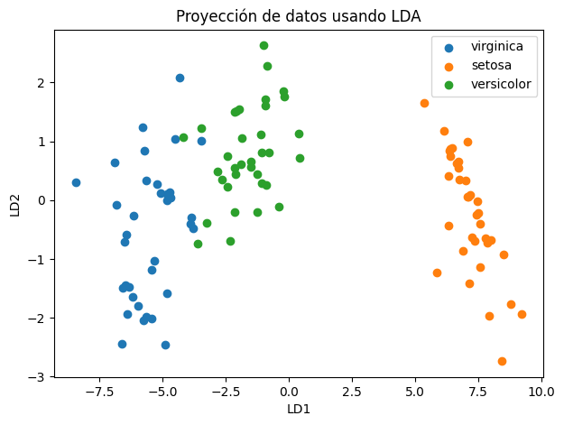

```python
import matplotlib.pyplot as plt

# convertir a dataframe para graficar
lda_df = pd.DataFrame(X_lda, columns=["LD1", "LD2"])
lda_df["Class"] = y_train.values

plt.figure(figsize=(7,5))

for especie in lda_df["Class"].unique():

    datos = lda_df[lda_df["Class"] == especie]

    plt.scatter(
        datos["LD1"],
        datos["LD2"],
        label=especie
    )

plt.xlabel("LD1")
plt.ylabel("LD2")
plt.title("Proyección de datos usando LDA")
plt.legend()

plt.show()
```

### 3.3 Interpretación geométrica de las funciones discriminantes

La figura anterior muestra la proyección de los datos de entrenamiento en el espacio generado por Linear Discriminant Analysis (LDA), utilizando las dos funciones discriminantes obtenidas: LD1 y LD2.

Cada punto en la gráfica representa una observación del conjunto de entrenamiento y su posición corresponde a la combinación lineal de las variables originales calculada por el modelo. Los diferentes colores identifican las tres especies de flores presentes en el dataset: setosa, versicolor y virginica.

A partir de la gráfica se observa que la primera función discriminante (LD1) logra separar de forma clara una de las clases respecto a las demás. En particular, la especie setosa aparece completamente separada hacia la derecha del gráfico, lo cual indica que las variables originales contienen suficiente información para distinguir esta especie mediante una frontera lineal.

Por otro lado, las especies versicolor y virginica se encuentran más cercanas entre sí dentro del espacio discriminante. Aunque existe cierta separación entre ambas clases, también se observa un ligero traslape entre algunos puntos. Esto sugiere que la distinción entre estas dos especies es más compleja y puede requerir fronteras de decisión más específicas para lograr una clasificación completamente precisa.

La segunda función discriminante (LD2) contribuye principalmente a mejorar la separación vertical entre las clases, permitiendo diferenciar mejor las observaciones que presentan características similares en la primera dimensión.

En conjunto, esta representación geométrica muestra que el modelo LDA es capaz de encontrar direcciones en el espacio de variables que maximizan la separación entre las distintas clases. La clara separación observada, especialmente en el caso de la especie setosa, sugiere que un modelo basado en fronteras lineales podría resultar adecuado para este problema de clasificación.

Esta visualización permite comprender de forma intuitiva cómo el modelo organiza los datos y proporciona una primera evidencia de que las variables medidas en las flores contienen información suficiente para distinguir entre las distintas especies.

### 3.4 Evaluación del modelo LDA

Aquí vamos a calcular:

- Accuracy
- Matriz de confusión
- Reporte de clasificación

```python
from sklearn.metrics import accuracy_score, confusion_matrix, classification_report

accuracy_lda = accuracy_score(y_test, y_pred_lda)
print("Accuracy del modelo LDA:")
print(accuracy_lda)

print("\nMatriz de confusión:")
print(confusion_matrix(y_test, y_pred_lda))

print("\nReporte de clasificación:")
print(classification_report(y_test, y_pred_lda))
```

```
Accuracy del modelo LDA:
1.0

Matriz de confusión:
[[15  0  0]
 [ 0 15  0]
 [ 0  0 15]]

Reporte de clasificación:
              precision    recall  f1-score   support

      setosa       1.00      1.00      1.00        15
  versicolor       1.00      1.00      1.00        15
   virginica       1.00      1.00      1.00        15

    accuracy                           1.00        45
   macro avg       1.00      1.00      1.00        45
weighted avg       1.00      1.00      1.00        45
```

Para evaluar el desempeño del modelo de Linear Discriminant Analysis (LDA) se utilizaron los datos del conjunto de prueba, los cuales no fueron utilizados durante el entrenamiento del modelo. Esto permite medir la capacidad del modelo para generalizar a nuevas observaciones.

El primer indicador calculado fue la exactitud (accuracy), que representa la proporción de predicciones correctas realizadas por el modelo. En este caso, el modelo obtuvo un valor de:

Accuracy=1.0

lo que significa que el modelo clasificó correctamente todas las observaciones del conjunto de prueba.

Para analizar con mayor detalle el comportamiento del modelo, también se calculó la matriz de confusión, la cual permite observar cómo se distribuyen las predicciones correctas e incorrectas entre las diferentes clases. La matriz obtenida fue la siguiente:

[15 0 0]

[ 0 15 0]

[ 0 0 15]

Esta matriz indica que las 15 observaciones de cada especie fueron clasificadas correctamente, sin errores de clasificación entre las distintas clases.

Adicionalmente, se calculó el reporte de clasificación, que incluye las métricas de precisión (precision), recuperación (recall) y F1-score para cada una de las clases. Los resultados muestran valores de 1.00 en todas las métricas para las tres especies, lo cual confirma que el modelo logró identificar correctamente cada una de las categorías.

Estos resultados sugieren que las variables presentes en el dataset Iris contienen suficiente información para separar adecuadamente las clases mediante combinaciones lineales, lo cual explica el excelente desempeño obtenido por el modelo LDA en este conjunto de datos.

La separación observada anteriormente en la representación geométrica del espacio discriminante coincide con estos resultados, ya que las clases aparecen claramente diferenciadas en el plano formado por LD1 y LD2, especialmente en el caso de la especie setosa. Esto indica que el modelo logró encontrar direcciones en el espacio de variables que permiten distinguir eficazmente entre las distintas especies.

### 3.5 Validación / Comprobación de estabilidad

#### 3.5.1 Accuracy en train vs test

```python
from sklearn.metrics import accuracy_score

print("Acc en train:", accuracy_score(y_train, lda.predict(X_train)))
print("Acc en test :", accuracy_score(y_test,  lda.predict(X_test)))
```

```
Acc en train: 0.9714285714285714
Acc en test : 1.0
```

Salida:

- Acc en train: 0.9714285714285714
- Acc en test : 1.0

Interpretación para el reporte

El desempeño no es artificial: el modelo no memoriza completamente el entrenamiento (train < test). El 1.0 en test se debe a que el split específico deja un conjunto de prueba “bien separable”.

#### 3.5.2 Sensibilidad al random_state (distintos splits)

```python
from sklearn.model_selection import train_test_split
from sklearn.discriminant_analysis import LinearDiscriminantAnalysis
from sklearn.metrics import accuracy_score

for rs in [1,2,3,4,5,10,42,100]:
    X_tr, X_te, y_tr, y_te = train_test_split(X, y, test_size=0.30, stratify=y, random_state=rs)
    lda2 = LinearDiscriminantAnalysis().fit(X_tr, y_tr)
    acc = accuracy_score(y_te, lda2.predict(X_te))
    print(rs, acc)
```

```
1 1.0
2 1.0
3 0.9777777777777777
4 0.9777777777777777
5 0.9555555555555556
10 1.0
42 0.9777777777777777
100 0.9777777777777777
```

El desempeño del LDA se mantiene alto en diferentes particiones, lo que indica estabilidad del modelo en Iris y que el resultado perfecto no es un error del procedimiento.

#### 3.5.3 Validación cruzada estratificada

```python
from sklearn.model_selection import StratifiedKFold, cross_val_score
from sklearn.discriminant_analysis import LinearDiscriminantAnalysis

cv = StratifiedKFold(n_splits=5, shuffle=True, random_state=0)
scores = cross_val_score(LinearDiscriminantAnalysis(), X, y, cv=cv, scoring="accuracy")

print("Accuracies CV:", scores)
print("Promedio:", scores.mean(), "Std:", scores.std())
```

```
Accuracies CV: [1.         1.         0.96666667 0.96666667 0.96666667]
Promedio: 0.9800000000000001 Std: 0.01632993161855452
```

La validación cruzada confirma que el desempeño promedio del modelo es ~98%, con variación baja entre folds. Esto respalda que LDA es altamente adecuado para este problema y que la evaluación no depende únicamente de un solo split.

### 3.6 Cierre del Apartado 3

En este apartado se construyó un modelo de clasificación basado en Linear Discriminant Analysis (LDA) utilizando el conjunto de entrenamiento (70% de los datos). Al proyectar las observaciones al espacio discriminante, se obtuvieron dos funciones (LD1 y LD2), lo cual es consistente con un problema de tres clases. La visualización en el plano (LD1, LD2) mostró una separación clara entre clases, especialmente para setosa, lo cual sugiere que una frontera lineal es adecuada.

En evaluación sobre el conjunto de prueba, el modelo obtuvo accuracy = 1.0 y una matriz de confusión sin errores. Para validar que este resultado no fuera producto de un caso particular, se comparó el desempeño en entrenamiento y prueba (train = 0.9714, test = 1.0), se evaluó el modelo en múltiples particiones con diferentes random_state (accuracy entre 0.9556 y 1.0) y se aplicó validación cruzada estratificada de 5 folds obteniendo una exactitud promedio de 0.98 ± 0.0163. En conjunto, estos resultados indican que LDA es un modelo muy adecuado y estable para la clasificación del dataset Iris.

## 4 Modelo basado en Árboles de Decisión

### 4.1 Construcción del modelo

A diferencia de Linear Discriminant Analysis (LDA), que construye fronteras lineales entre las clases, los árboles de decisión utilizan un enfoque basado en reglas jerárquicas para realizar la clasificación.

Este modelo divide el espacio de variables mediante una serie de condiciones sobre las variables predictoras. Cada nodo del árbol representa una decisión basada en el valor de una variable, y cada división busca reducir la impureza de los datos dentro de los subconjuntos resultantes.

De esta manera, el árbol genera una estructura jerárquica donde cada camino desde la raíz hasta una hoja representa una regla de clasificación.

Una ventaja importante de los árboles de decisión es su interpretabilidad, ya que permiten identificar fácilmente qué variables tienen mayor influencia en la clasificación y cómo se construyen las decisiones del modelo.

```python
from sklearn.tree import DecisionTreeClassifier

# crear modelo
tree = DecisionTreeClassifier(random_state=0)

# entrenar modelo
tree.fit(X_train, y_train)

# realizar predicciones
y_pred_tree = tree.predict(X_test)
```

### 4.2 Visualización del árbol

La visualización del árbol permite observar cómo el modelo organiza las decisiones y qué variables utiliza para separar las distintas clases.

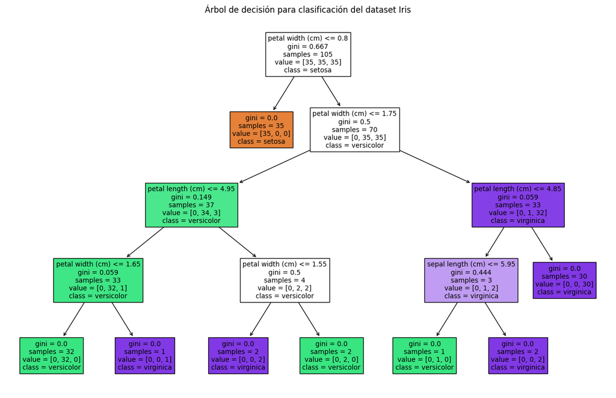

```python
from sklearn.tree import plot_tree
import matplotlib.pyplot as plt

plt.figure(figsize=(16,10))

plot_tree(
    tree,
    feature_names=X.columns,
    class_names=tree.classes_,
    filled=True
)

plt.title("Árbol de decisión para clasificación del dataset Iris")

plt.show()
```

### 4.3 Interpretación del árbol de decisión

La figura anterior muestra la estructura del árbol de decisión entrenado utilizando el conjunto de datos de entrenamiento. Cada nodo del árbol representa una condición basada en una variable predictora, mientras que las ramas indican las decisiones que el modelo toma para clasificar las observaciones.

El nodo raíz, que representa la primera división del árbol, utiliza la variable petal width (cm) con la condición:

petal width≤0.8

Esta primera división es especialmente importante, ya que separa de forma inmediata a la especie setosa del resto de las clases. En el lado izquierdo del árbol se observa un nodo con gini = 0, lo que indica que todas las observaciones que cumplen esa condición pertenecen a la misma clase. Esto confirma que la especie setosa posee características claramente diferenciadas en comparación con las otras especies del dataset.

En el lado derecho del árbol se encuentran las observaciones correspondientes a versicolor y virginica, las cuales requieren divisiones adicionales para poder ser separadas correctamente. En estas ramas, el árbol utiliza principalmente las variables petal width y petal length para realizar nuevas divisiones.

Por ejemplo, una de las reglas generadas por el modelo puede interpretarse de la siguiente manera:

- Si petal width ≤ 0.8, entonces la flor pertenece a la especie setosa.

Mientras que para distinguir entre versicolor y virginica, el modelo utiliza reglas adicionales como:

- Si petal width ≤ 1.75 y petal length ≤ 4.95, entonces la flor se clasifica como versicolor.
- Si petal width > 1.75, entonces la flor se clasifica como virginica.

En general, el árbol de decisión logra construir una serie de reglas claras que permiten clasificar correctamente las observaciones. Además, su estructura jerárquica facilita la interpretación del modelo, permitiendo entender de forma intuitiva cómo se toman las decisiones de clasificación.

### 4.4 Evaluación del árbol de decisión

```python
from sklearn.metrics import accuracy_score, confusion_matrix, classification_report

accuracy_tree = accuracy_score(y_test, y_pred_tree)

print("Accuracy del árbol de decisión:")
print(accuracy_tree)

print("\nMatriz de confusión:")
print(confusion_matrix(y_test, y_pred_tree))

print("\nReporte de clasificación:")
print(classification_report(y_test, y_pred_tree))
```

```
Accuracy del árbol de decisión:
0.9777777777777777

Matriz de confusión:
[[15  0  0]
 [ 0 15  0]
 [ 0  1 14]]

Reporte de clasificación:
              precision    recall  f1-score   support

      setosa       1.00      1.00      1.00        15
  versicolor       0.94      1.00      0.97        15
   virginica       1.00      0.93      0.97        15

    accuracy                           0.98        45
   macro avg       0.98      0.98      0.98        45
weighted avg       0.98      0.98      0.98        45
```

Para evaluar el desempeño del modelo de árbol de decisión se utilizaron las mismas métricas empleadas en el modelo LDA: accuracy, matriz de confusión y reporte de clasificación. Estas métricas permiten analizar tanto el desempeño global del modelo como su comportamiento específico en cada una de las clases.

El modelo obtuvo una exactitud (accuracy) de 0.9778, lo que indica que el árbol clasificó correctamente aproximadamente el 97.8% de las observaciones del conjunto de prueba.

La matriz de confusión obtenida fue la siguiente:

[[15 0 0]

[ 0 15 0]

[ 0 1 14]]

Esta matriz muestra que las clases setosa y versicolor fueron clasificadas correctamente en todas sus observaciones. Sin embargo, se observa un pequeño error de clasificación en la especie virginica, donde una de las observaciones fue clasificada incorrectamente como versicolor.

El reporte de clasificación muestra valores elevados de precision, recall y F1-score para todas las clases. En particular:

- setosa presenta valores perfectos en todas las métricas.
- versicolor obtiene un F1-score de aproximadamente 0.97.
- virginica también presenta un F1-score cercano a 0.97, aunque con una ligera reducción en el recall debido al error de clasificación mencionado anteriormente.

En términos generales, el árbol de decisión muestra un desempeño muy alto, aunque ligeramente inferior al obtenido por el modelo LDA. Esto sugiere que, si bien el árbol logra capturar adecuadamente la estructura de los datos, la separación lineal encontrada por LDA resulta ligeramente más efectiva para este conjunto de datos específico.

### 4.5 Poda del árbol de decisión

Los árboles de decisión pueden crecer demasiado y adaptarse excesivamente a los datos de entrenamiento, fenómeno conocido como sobreajuste (overfitting). Cuando esto ocurre, el modelo puede capturar patrones muy específicos del conjunto de entrenamiento que no necesariamente se generalizan bien a nuevos datos.

Para controlar la complejidad del árbol se utiliza el método de poda por complejidad de costo (Cost Complexity Pruning). Este método introduce un parámetro de regularización denominado α (ccp_alpha), el cual penaliza la complejidad del árbol.

El parámetro α controla el tamaño del árbol de la siguiente manera:

- α pequeño → árbol más grande y complejo
- α grande → árbol más simple

El objetivo es encontrar el valor de α que proporcione el mejor equilibrio entre precisión del modelo y simplicidad de la estructura del árbol.

```python
from sklearn.model_selection import StratifiedKFold, cross_val_score
import numpy as np

skf = StratifiedKFold(n_splits=4, shuffle=True, random_state=0)

alphas = np.linspace(0,0.05,200)

scores = []

for alpha in alphas:

    tree_temp = DecisionTreeClassifier(
        random_state=0,
        ccp_alpha=alpha
    )

    score = cross_val_score(
        tree_temp,
        X_train,
        y_train,
        cv=skf,
        scoring="f1_macro"
    ).mean()

    scores.append(score)

alpha_opt = alphas[np.argmax(scores)]

print("Alpha óptimo:", alpha_opt)
```

```
Alpha óptimo: 0.015829145728643218
```

Para seleccionar el valor óptimo de α se realizó una validación cruzada estratificada de 4 particiones, evaluando el desempeño del modelo mediante el F1-score macro.

A partir de este procedimiento se obtuvo el siguiente valor óptimo:

αopt=0.01583

Este valor corresponde al parámetro que maximiza el desempeño promedio del modelo durante el proceso de validación cruzada.

### 4.6 Selección del parámetro de poda

La gráfica anterior muestra la relación entre el parámetro ccp_alpha y el desempeño del modelo medido mediante F1-score en validación cruzada.

Se observa que el desempeño del modelo mejora al aumentar ligeramente el valor de α hasta alcanzar un máximo cercano a 0.0158. A partir de este punto, el desempeño se mantiene relativamente estable, lo que indica que valores mayores de α no aportan mejoras adicionales al modelo.

Esta gráfica permite identificar visualmente el punto donde el árbol alcanza un buen equilibrio entre simplicidad y capacidad predictiva, evitando tanto el sobreajuste como una simplificación excesiva del modelo.

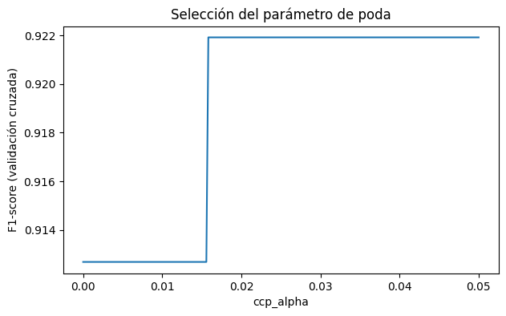

```python
plt.figure(figsize=(7,4))

plt.plot(alphas, scores)

plt.xlabel("ccp_alpha")
plt.ylabel("F1-score (validación cruzada)")
plt.title("Selección del parámetro de poda")

plt.show()
```

### 4.7 Construcción del árbol podado

Ahora entrenamos el árbol usando el α óptimo.

```python
tree_pruned = DecisionTreeClassifier(
    random_state=0,
    ccp_alpha=alpha_opt
)

tree_pruned.fit(X_train, y_train)

y_pred_pruned = tree_pruned.predict(X_test)
```

### 4.8 Evaluación del árbol podado

```python
from sklearn.metrics import accuracy_score, confusion_matrix, classification_report

accuracy_pruned = accuracy_score(y_test, y_pred_pruned)

print("Accuracy del árbol podado:")
print(accuracy_pruned)

print("\nMatriz de confusión:")
print(confusion_matrix(y_test, y_pred_pruned))

print("\nReporte de clasificación:")
print(classification_report(y_test, y_pred_pruned))
```

```
Accuracy del árbol podado:
0.9777777777777777

Matriz de confusión:
[[15  0  0]
 [ 0 15  0]
 [ 0  1 14]]

Reporte de clasificación:
              precision    recall  f1-score   support

      setosa       1.00      1.00      1.00        15
  versicolor       0.94      1.00      0.97        15
   virginica       1.00      0.93      0.97        15

    accuracy                           0.98        45
   macro avg       0.98      0.98      0.98        45
weighted avg       0.98      0.98      0.98        45
```

### 4.9 Visualización del árbol podado

Para analizar el efecto de la poda sobre la estructura del modelo, se puede visualizar nuevamente el árbol de decisión utilizando el valor óptimo de α obtenido previamente. Esta visualización permite comparar la complejidad del árbol podado con la del árbol original.

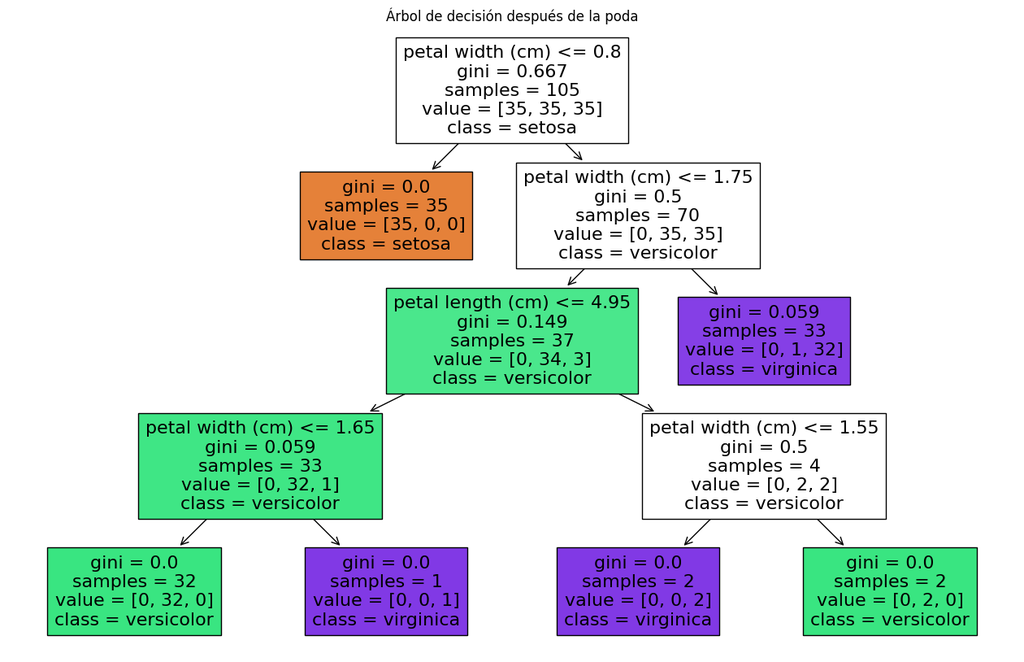

```python
plt.figure(figsize=(16,10))

plot_tree(
    tree_pruned,
    feature_names=X.columns,
    class_names=tree_pruned.classes_,
    filled=True
)

plt.title("Árbol de decisión después de la poda")

plt.show()
```

La figura anterior muestra la estructura del árbol de decisión después de aplicar el proceso de poda utilizando el parámetro α óptimo obtenido mediante validación cruzada.

En particular, el nodo raíz continúa utilizando la variable petal width (cm) como primera condición de separación, lo cual confirma que esta variable posee un alto poder discriminativo entre las especies de flores. Asimismo, las variables relacionadas con petal length y petal width siguen siendo las principales responsables de separar las clases versicolor y virginica.

El hecho de que el árbol podado mantenga una estructura similar al árbol original sugiere que el modelo inicial no presentaba un sobreajuste significativo, y que las divisiones generadas eran consistentes con la estructura real de los datos.

### 4.10 Conclusión del modelo de árbol de decisión

El modelo de árbol de decisión mostró un desempeño alto en la tarea de clasificación del dataset Iris, obteniendo una exactitud de aproximadamente 0.978 en el conjunto de prueba. La matriz de confusión indica que la mayoría de las observaciones fueron clasificadas correctamente, con únicamente un pequeño error en la clasificación de una observación de la especie virginica.

Posteriormente, se aplicó un proceso de poda mediante el parámetro ccp_alpha, con el objetivo de reducir la complejidad del árbol y prevenir posibles problemas de sobreajuste. El valor óptimo obtenido mediante validación cruzada fue α ≈ 0.0158.

Al evaluar el árbol podado se observó que el desempeño del modelo se mantiene prácticamente igual al del árbol original, lo cual sugiere que el modelo inicial ya presentaba una estructura adecuada para describir las relaciones presentes en los datos.

En general, el árbol de decisión permite generar reglas de clasificación claras e interpretables, mostrando que las variables asociadas al tamaño de los pétalos son las más relevantes para distinguir entre las distintas especies de flores.

## 5. Comparación entre LDA y Árbol de decisión

Con el objetivo de determinar cuál de los modelos resulta más adecuado para este problema de clasificación, se compararon los resultados obtenidos mediante Linear Discriminant Analysis (LDA) y árboles de decisión.

La siguiente tabla resume la exactitud obtenida por cada modelo en el conjunto de prueba:

```python
import pandas as pd

comparacion = pd.DataFrame({
    "Modelo": ["LDA", "Árbol de decisión"],
    "Accuracy": [accuracy_lda, accuracy_tree],
})

comparacion
```

|  | Modelo | Accuracy |
| --- | --- | --- |
| 0 | LDA | 1.000000 |
| 1 | Árbol de decisión | 0.977778 |

A partir de estos resultados se observa que ambos modelos presentan un desempeño muy alto, logrando clasificar correctamente la gran mayoría de las observaciones del dataset. Sin embargo, el modelo LDA obtuvo una exactitud ligeramente mayor, alcanzando una clasificación perfecta en el conjunto de prueba.

Desde una perspectiva geométrica, el modelo LDA mostró una clara separación entre las clases en el espacio generado por las funciones discriminantes LD1 y LD2. En particular, la especie setosa se separa completamente de las otras clases, mientras que versicolor y virginica presentan una ligera proximidad, aunque siguen siendo diferenciables mediante combinaciones lineales de las variables.

Por otro lado, el modelo de árbol de decisión construyó una serie de reglas jerárquicas basadas principalmente en las variables petal width y petal length, las cuales demostraron ser las más relevantes para distinguir entre las especies. Aunque el árbol logró un desempeño muy alto, se observó un pequeño error de clasificación en una de las observaciones de la especie virginica.

Otra diferencia importante entre ambos enfoques radica en su interpretabilidad. Mientras que LDA se basa en combinaciones lineales de las variables que pueden ser menos intuitivas de interpretar, los árboles de decisión generan reglas claras y fácilmente comprensibles, lo que facilita entender cómo el modelo toma sus decisiones.

En términos generales, ambos modelos resultan adecuados para este problema de clasificación. No obstante, considerando el desempeño obtenido en las métricas de evaluación y la clara separación observada en el espacio discriminante, el modelo LDA puede considerarse ligeramente más adecuado para este dataset específico.

## Conclusión

En este análisis se aplicaron dos enfoques diferentes de clasificación supervisada al dataset Iris: Linear Discriminant Analysis (LDA) y árboles de decisión. Ambos modelos lograron identificar patrones relevantes en las variables predictoras, permitiendo distinguir entre las distintas especies de flores con un alto nivel de precisión.

El modelo LDA mostró una excelente capacidad para separar las clases mediante combinaciones lineales de las variables, obteniendo una exactitud perfecta en el conjunto de prueba y un desempeño promedio cercano al 98% en validación cruzada. La representación geométrica en el espacio de funciones discriminantes permitió visualizar claramente la separación entre las clases.

Por su parte, el modelo de árbol de decisión también presentó un desempeño muy alto y permitió generar reglas de clasificación claras e interpretables. Además, el proceso de poda mediante el parámetro ccp_alpha confirmó que el árbol original ya presentaba una complejidad adecuada para describir los patrones presentes en los datos.

En conclusión, ambos modelos resultan efectivos para la clasificación del dataset Iris. Sin embargo, debido a su mayor exactitud y a la clara separación observada en el espacio discriminante, LDA se presenta como el modelo más adecuado para este problema específico.

#### Referencias

Dataset:

- Fisher, R. A. (1936). Iris dataset. UCI Machine Learning Repository. https://archive.ics.uci.edu/dataset/53/iris